# PA1_template

DataRacer11

August 7, 2015

## Coursera Course - RepData_PeerAssessment1- “Reproducible Research”

#### by Roger D. Peng, PhD, Jeff Leek, PhD, Brian Caffo, PhD

**Date:** 08-16-2015

**Course Student: [DataRacer11](https://github.com/DataRacer11/RepData_PeerAssessment1)**

- **This Assignment with Code begins at:** **Loading and pre-processing the data section**

**File Name:** RepData.R (contains all plotting code for all 3 questions in one .R file).

**Project [Location](https://class.coursera.org/repdata-031/human_grading/view/courses/975144/assessments/3/submissions)**

**Data [File Location](https://d396qusza40orc.cloudfront.net/repdata%2Fdata%2Factivity.zip)**

**References:**

**[GitHub](https://github.com/)**

**Exploratory Data Analysis with R, The Book + Lecture Videos (HD) + Datasets + R Code Files [by Roger D. Peng, PhD](https://leanpub.com/exdata)**

**[Plotting in R](http://www.r-bloggers.com/how-to-plot-a-graph-in-r/)**

**Please review this README.MD file on [Github](https://github.com/rdpeng/RepData_PeerAssessment1/blob/master/README.md)**

## Introduction

### Information about the study design

It is now possible to collect a large amount of data about personal movement using activity monitoring devices such as a [Fitbit](http://www.fitbit.com/), [Nike Fuelband](http://www.nike.com/us/en_us/c/nikeplus-fuelband), or [Jawbone Up](https://jawbone.com/up). These type of devices are part of the “quantified self” movement – a group of enthusiasts who take measurements about themselves regularly to improve their health, to find patterns in their behavior, or because they are tech geeks. But these data remain under-utilized both because the raw data are hard to obtain and there is a lack of statistical methods and software for processing and interpreting the data.

This assignment makes use of data from a personal activity monitoring device. This device collects data at 5 minute intervals through out the day. The data consists of two months of data from an anonymous individual collected during the months of October and November, 2012 and include the number of steps taken in 5 minute intervals each day.

## Data

The data for this assignment can be downloaded from the course web site:

- Dataset: Activity monitoring data [52K]

The variables included in this dataset are:

- **steps**: Number of steps taking in a 5-minute interval (missing values are coded as `NA`)
- **date**: The date on which the measurement was taken in YYYY-MM-DD format
- **interval**: Identifier for the 5-minute interval in which measurement was taken

The dataset is stored in a comma-separated-value (CSV) file and there are a total of 17,568 observations in this dataset.

## Assignment

This assignment will be described in multiple parts. You will need to write a report that answers the questions detailed below. Ultimately, you will need to complete the entire assignment in a **single R markdown** document that can be processed by **knitr** and be transformed into an HTML file.

Throughout your report make sure you always include the code that you used to generate the output you present. When writing code chunks in the R markdown document, always use `echo = TRUE` so that someone else will be able to read the code. **This assignment will be evaluated via peer assessment so it is essential that your peer evaluators be able to review the code for your analysis**.

For the plotting aspects of this assignment, feel free to use any plotting system in R (i.e., base, lattice, ggplot2)

Fork/clone the [GitHub repository created for this assignment](http://github.com/rdpeng/RepData_PeerAssessment1). You will submit this assignment by pushing your completed files into your forked repository on GitHub. The assignment submission will consist of the URL to your GitHub repository and the SHA-1 commit ID for your repository state.

NOTE: The GitHub repository also contains the dataset for the assignment so you do not have to download the data separately.

### Loading and pre-processing the data

#### Show any code that is needed to:

#### Load the data (i.e. `read.csv()`)

- **Set the working directory** (i.e. setwd())
- **Check for correct working directory** with .csv data (i.e. getwd())
- **Load required R Packages:**(either `library` or `require` can be used)
- **In RStudio the install `lubridate` library**

```
library(lubridate)
```

- **Dataset:** Activity monitoring data [52K]* (see above link and on [GitHub](https://github.com/rdpeng/RepData_PeerAssessment1))
- **Download file:** https://d396qusza40orc.cloudfront.net/repdata%2Fdata 2Factivity.zip (see above link and on [GitHub](https://github.com/rdpeng/RepData_PeerAssessment1))
- **Unzip the file: (i.e. unzip(“repdata-data-activity.zip”)**

```
data = read.csv("activity.csv", header = TRUE)
```

```
str(data)
```

#### Observe the Data:

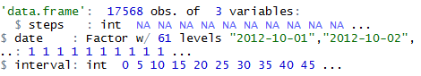

#### Process/transform the data (if necessary) into a format suitable for your analysis

- Lubridate “wday” function can transform the data to print the Weekday names as variables.
- `as.Date` function is used to convert between character representations and objects of class “Date” representing calendar dates.

```
data$date<-as.Date(data$date)
```

- Date-time must be a POSIXct, POSIXlt, Date, chron, yearmon, yearqtr, zoo, zooreg, timeDate, xts, its, ti, jul, timeSeries, and fts objects.
- wday returns the day of the week as a decimal number (01-07, Sunday is 1)

```
data$Weekday<-wday(data$date, label = TRUE, abbr = FALSE)
```

- **Divide** data into Groups and Reassemble. `Split` divides the data in the vector x into the groups. The replacement forms replace values corresponding to such a division.
- `sapply` is a user-friendly version and wrapper of lapply by default returning a vector, matrix
- **Calculate** the total number of steps per day

```
Steps_Each_Day = sapply(split(data$steps, data$date), sum)
```

#### Observe the Data:

[output not shown]

```
tail(data)
```

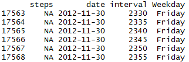

### What is mean total number of steps taken per day?

###### For this part of the assignment, you can ignore the missing values in the dataset.

- **Make a histogram** of the total number of steps taken each day

```
hist(Steps_Each_Day, col = "lightblue", main = "Total Number of Steps Each Day", ylim = c(0, 40))
```

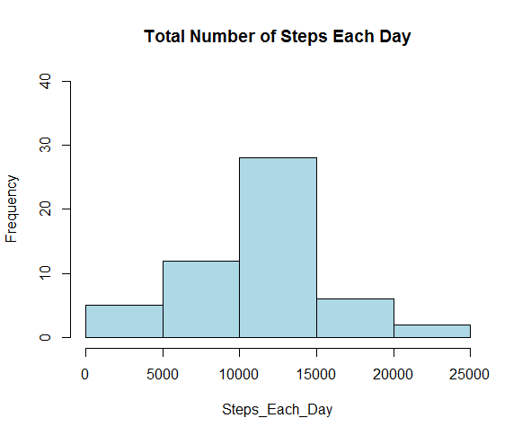

- **Calculate** and **report** the mean of the total number of steps taken per day

```
print(mean(Steps_Each_Day, na.rm = TRUE))
```

**`##[1] 10766.19`**

- **Calculate** and **report** the median of the total number of steps taken per day

```
print(median(Steps_Each_Day, na.rm = TRUE))
```

**`##[1] 10765`**

### What is the average daily activity pattern?

- **Make a time series plot** (i.e. `type = "l"`) of the 5-minute interval (x-axis) and the average number of steps taken, averaged across all days (y-axis)

```
Avg_Daily_Activity = sapply(split(data$steps, data$interval), mean, na.rm = TRUE)
```

- Which 5-minute interval, on average across all the days in the dataset, contains the maximum number of steps?

```
names(Avg_Daily_Activity)[Avg_Daily_Activity == max(Avg_Daily_Activity)]
```

- Interval with maximum number of mean steps.

**`##[1] 835`**

- **Print** out the Interval with maximum number of mean steps and the max average number of steps per interval

```
print(Avg_Daily_Activity)[Avg_Daily_Activity == max(Avg_Daily_Activity)]
```

**`##[1] 835`**

**`##[1] 206.1698`**

[output not shown]

[figure not shown]

### Imputing missing values

Note that there are a number of days/intervals where there are missing values (coded as `NA`). The presence of missing days may introduce bias into some calculations or summaries of the data.

- **Calculate** and **report** the total number of missing values in the dataset (i.e. the total number of rows with `NA`s)
- **Calculate** the total number of rows with NAs)

```
sum(is.na(data$steps))
```

**`##[1] 2304`**

#### Observe the Data:

```
summary(data)
```

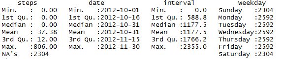

- **Devise a strategy** for filling in all of the missing values in the dataset. The strategy does not need to be sophisticated. For example, you could use the mean/median for that day, or the mean for that 5-minute interval, etc.
- **Subset** out all of the 2304 rows with an NA value

```
NA_data <- subset(data, !complete.cases(data))
```

- **NOTE:** All of the NAs are contained in 8 days, which have all steps missing in each day

#### Observe the Data:

[output not shown]

- **Create** a new dataset that is equal to the original dataset but with the missing data filled in.

[output not shown]

- **Sum** the missing NA values which now show as replaced and filled with data.

```
sum(is.na(fillData$steps))
```

**`##[1] 0`**

- **Make a histogram** of the total number of steps taken each day
- **Calculate** and **report** the mean and median total number of steps taken per day.

```
Total_Number_Steps_NA_Filled_Per_Interval = sapply(split(fillData$steps, fillData$date), sum)
hist(Total_Number_Steps_NA_Filled_Per_Interval, col = "green", ylim = c(0, 40),
main = "New Histogram with NA Data Filled")
```

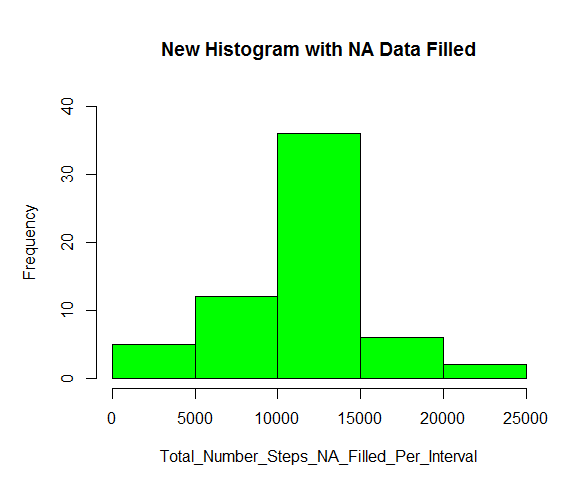

- Do these values differ from the estimates from the first part of the assignment? What is the impact of imputing missing data on the estimates of the total daily number of steps?
- **Calculate** and **report** the mean total number of steps taken per day.

```
print(mean(Total_Number_Steps_NA_Filled_Per_Interval, na.rm = TRUE))
```

**`##[1] 10766.19`**

- **Calculate** and **report** the median total number of steps taken per day.

```
print(median(Total_Number_Steps_NA_Filled_Per_Interval, na.rm = TRUE))
```

**`##[1] 10766.19`**

### Are there differences in activity patterns between weekdays and weekends?

- No, the mean of total values do not differ the from the estimates from the first part of the assignment.

### What is the impact of imputing missing data on the estimates of the total daily number of steps?

- The original averages for each day that did not show as NA remain unchanged.
- The overall values may show to be slightly higher with a more rigid and more sophisticated strategy however as a cursory look though the .csv file.
- A quick exploratory analysis of plotting the days (many plots not included in this document) showed the imputed days that were missing tended to be Wednesdays, and Thursday through Friday of the week.
- These days appear to have increased steps activity.
- **Create** a new factor variable in the dataset with two levels – “weekday” and “weekend” indicating whether a given date is a weekday or weekend day.
- For this part the `weekdays()` function is helpful.
- **Use** the dataset with the filled-in missing values for this part.

```
fillData$weekday = weekdays(as.Date(fillData$date, format = "%Y-%m-d"))
fillData$weekday_type = factor(ifelse(fillData$weekday == "Sunday"
| fillData$weekday == "Saturday", "weekend", "weekday"),
levels = c("weekday", "weekend"))
```

- **Calculate** the average number of steps per interval, group by weekday and by weekend day

```
fillData_weekdays = fillData[fillData$weekday_type == "weekday",]
fillData_weekend = fillData[fillData$weekday_type == "weekend",]
avg_number_steps_interval_weekdays= sapply(split(fillData_weekdays$steps, fillData_weekdays$interval), mean)
avg_number_steps_interval_weekend = sapply(split(fillData_weekend$steps, fillData_weekend$interval),mean)
```

- **Make** a panel plot containing a time series plot (i.e. `type = "l"`) of the 5-minute interval (x-axis) and the average number of steps taken, averaged across all weekday days or weekend days (y-axis).

```
MyPlot = function() {`
par(mfrow = c(2, 1), mar = c(4, 5, 2, 2)
plot(avg_number_steps_interval_weekend, col= "violetred2", type = "l",
yaxt = "n", ylim = c(0, 250),
xlim = c(0, 300),
main = "weekend", ylab = "", xlab = "Interval", col.lab="violetred2",
col.main="violetred2")
axis(side = 2, at = seq(0, 250, 50), labels = seq(0, 250, 50))
plot(avg_number_steps_interval_weekdays, col="darkorchid4", type = "l", ylim = c(0, 250), xlim = c(0, 300), main = "weekday", ylab = "", xlab = "Interval", col.main="darkorchid4", col.lab="darkorchid4")
par(mfrow = c(1, 1), mar = c(3, 2, 2, 2))
mtext(text = "Number of steps", side = 2, col="blue")
par(mar = c(5, 5, 5, 2))
}
```

```
MyPlot()
```

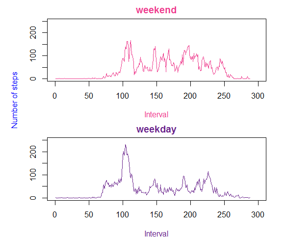

## Submitting the Assignment

To submit the assignment:

1. Commit your completed `PA1_template.Rmd` file to the `master` branch of your git repository (you should already be on the `master` branch unless you created new ones)
2. Commit your `PA1_template.md` and `PA1_template.html` files produced by processing your R markdown file with the `knit2html()` function in R (from the **[knitr](https://en.wikipedia.org/wiki/Knitr)** package)

3. If your document has figures included (it should) then they should have been placed in the `figure/` directory by default (unless you overrode the default). Add and commit the `figure/` directory to your git repository.
4. Push your `master` branch to GitHub.
5. Submit the URL to your GitHub repository for this assignment on the course web site.

In addition to submitting the URL for your GitHub repository, you will need to submit the 40 character SHA-1 hash (as string of numbers from 0-9 and letters from a-f) that identifies the repository commit that contains the version of the files you want to submit. You can do this in GitHub by doing the following:

1. Go into your GitHub repository web page for this assignment
2. Click on the “?? commits” link where ?? is the number of commits you have in the repository. For example, if you made a total of 10 commits to this repository, the link should say “10 commits”.
3. You will see a list of commits that you have made to this repository. The most recent commit is at the very top. If this represents the version of the files you want to submit, then just click the “copy to clipboard” button on the right hand side that should appear when you hover over the SHA-1 hash. Paste this SHA-1 hash into the course web site when you submit your assignment. If you don’t want to use the most recent commit, then go down and find the commit you want and copy the SHA-1 hash.

A valid submission will look something like (this is just an **example**! (See [Github](https://github.com/rdpeng/RepData_PeerAssessment1))

[SHA-1 hash:](https://github.com/rdpeng/RepData_PeerAssessment1/commits/master) 7c376cc5447f11537f8740af8e07d6facc3d9645